# Birds of the same feather…

Carlos J. Gil Bellosta

2016-04-14

# Motivación: una consulta y muchos ficheros

# Leer muchos ficheros pequeños…

- Un directorio con cientos de ficheros pequeños
- Ocupan, en total, varios gigas
- Todos con la misma estructura
- ¿Cómo consultar la información eficientemente?

# read.table: flexible y lenta

- `read.table` es *óptima*
- Solo que optimiza varios criterios a la vez
- (O es una optimización restringida, más bien)
- Quiere ser muy flexible (véanse los parámetros que admite)
- Léase también `?read.table` con detenimiento para descubrir *trucos*

# Moderneces eficientes

- `data.table::fread`
- `readr::read_table`
- ¿etc.?
- Resumen: menos flexibles, más rápidas

# El cuello de botella

- Las *moderneces* tienen un *techo* de eficiencia
- ¡Es el elefante en el salón!

# Ficheros orientados a filas

# Ficheros de texto

[figure not shown]

- Para leer la fila 45 hay que leer las 44 anteriores necesariamente
- ¡No se sabe de antemano dónde están los EOL!

# Bases de datos (tradicionales)

- Guardan los datos en *filas*
- Además, las filas tienen *encabezados*; p.e., el de Postgres:

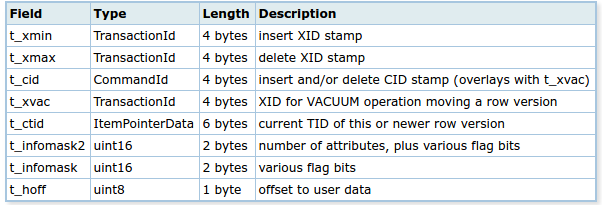

- ¡Son +20 bytes por fila!

# Ficheros orientados a columnas

# Una tabla es un vector de columnas

- Ventajas:
  - No siempre se quieren todas las columnas
  - Compresión
- Inconvenientes:
  - Inserciones y borrados (ETL)

(Eso es lo que veréis en cualquier *benchmark*).

# Uso de tablas orientadas a columnas

# Volvemos al cuello de botella

- Al leer un CSV en R, los registros se leen por filas y se guardan por columnas
- Lo mismo al leer de una base de datos (p.e., con un cursor)
- ¡Incluso si se leen datos de una base de datos columnar!

# El cuello de botella, gráficamente

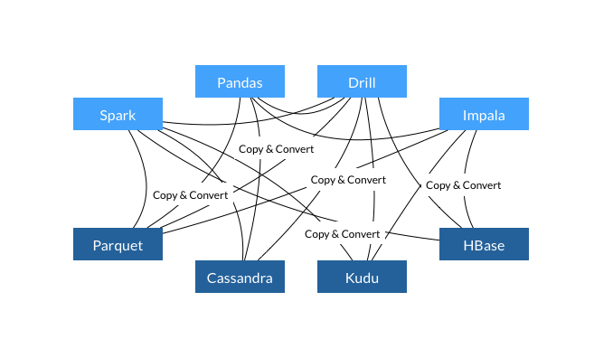

# Ficheros nativos de R

# Ficheros .Rdat

- Contienen versiones *serializadas* de objetos de R (comprimidas o no)
- Se crean con `save`
- `load` *restaura* los objetos originales del fichero en memoria
- Una tabla se guarda por columnas

# Ficheros .rds

- Contienen un único objeto de R serializado
- Se crean con la función `saveRDS`
- Se leen con `readRDS`

```r
saveRDS(women, "women.rds")
women2 <- readRDS("women.rds")
identical(women, women2)
```

# Feather

# feather-format

- Es un formato binario para tablas
- Las almacena por columnas
- Es común a R y Python
- Está basado en (o es un *dialecto* de) `arrow`

# Arrow: el objetivo

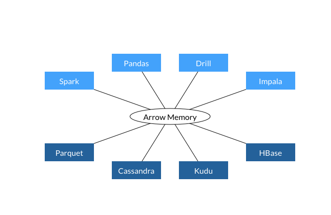

# Arrow especifica cómo almacenar vectores

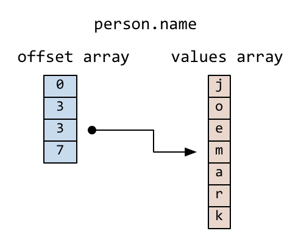

# Y feather lo hace

```
for (int i = 0; i < n; ++i) {
    SEXP xi = STRING_ELT(x, i);

    if (xi == NA_STRING) {
      length = 0;
      ++n_missing;
    } else {
      // Valid
      util::set_bit(nulls, i);
      const char* utf8 = Rf_translateCharUTF8(xi);
      length = strlen(utf8);
      data_builder.Append(reinterpret_cast<const uint8_t*>(utf8), length);
    }

    offsets[i] = offset;
    offset += length;
  }
```

# Tablas en arrow/feather

- Son listas de grupos de columnas (vectores)
- Cada grupo de columnas contiene un tajo horizontal de la tabla
- Dentro de cada grupo de columnas, las columnas se almacenan como vectores
- Gracias a los metadatos (*offsets*, etc.) se puede acceder rápidamente a los bloques (contiguos a cachos) donde reside una columna

# Tablas en parquet

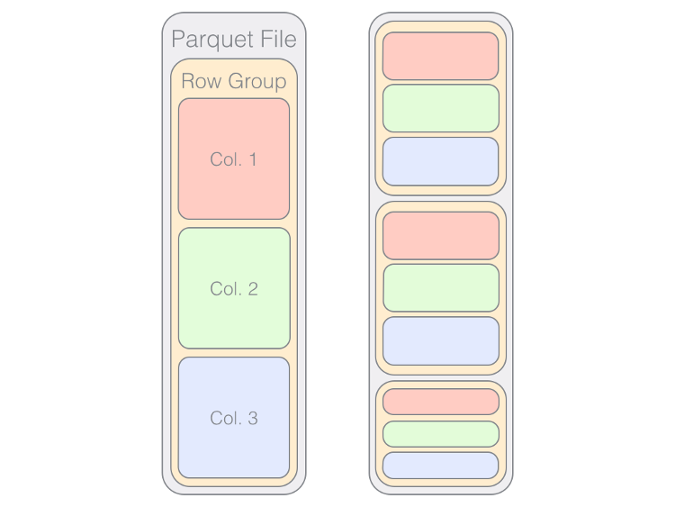

# Feather en funcionamiento

Véase [mi blog](https://www.datanalytics.com/2016/04/06/rpython-feather/)

# Comentarios

- No tengo claro si para alguien que solo use R, `feather` es mejor que los formatos nativos de R
- Puede ser muy útil si en lugar de usar JDBC o similares los contenedores de datos pudiesen generar ficheros `feather`